## Algorithme d'apprentissage d'un réseau de neurones

**Théorie :**

- Descente de gradient

### Descente de gradient

Un réseau est entrainé en deux phases : la **forward pass** et la **backward pass**. La forward pass correspond à faire passer les exemples d'entrainement dans le réseau et de caculer la loss correspondante. La backward pass consiste à mettre à jour les poids du réseau pour minimiser cette loss lors des prochaines forward pass. Cette procédure est répétée jusqu'à convergence, on appelle cela l'entraînement du réseau.

Prenons une classification binaire, linéairement séparable, avec des $x \in \mathbb{R}^2$, ainsi il nous faut uniquement un NN composé d'un perceptron avec un poids $w = \{w_1, w_2\}$. Nous allons prendre 100 points pour ces deux poids entre $-10$ et $5$, et pour chaque combinaison ($100^2$) de poids calculer la loss pour ce problème.

Définissons d'abord le réseau et la loss:

```python
from sklearn.datasets import make_blobs
import numpy as np  # Matrix and vector computation package
import matplotlib.pyplot as plt  # Plotting library
from matplotlib import cm # Colormaps
from mpl_toolkits.mplot3d import Axes3D  # 3D plots
import seaborn as sns  # Fancier plots


X, y = make_blobs(n_samples=40, centers=2, random_state=6, center_box=(-1.0, 1.0), cluster_std=0.6)
y = y.reshape(-1,1)

# Define the loss function
def loss(y, t):
    return - np.mean(
        np.multiply(t, np.log(y)) + np.multiply((1-t), np.log(1-y)))

def logistic(zo):
    return 1. / (1. + np.exp(-zo))

def nn(x, w):
    return logistic(x.dot(w.T))
```

On calcul la loss pour chaque combinaison de poids :

```python
grid_size = 100
w1 = np.linspace(-10, 5, num=grid_size) #  100 points entre 5 et -5 pour poids b
w2 = np.linspace(-10, 5, num=grid_size) #  100 points entre 5 et -5 pour poids b
params_x, params_y = np.meshgrid(w1, w2) # generate grid
loss_grid = np.zeros((grid_size, grid_size))

# On calcul la loss pour chaque combinaison des 2 poids
for i in range(grid_size):
    for j in range(grid_size):
        loss_grid[i,j] = loss(
            nn(X, np.asmatrix([params_x[i,j], params_y[i,j]])) , y)
```

On plot le grid de cette loss :

[figure not shown]

```python
# Plot the loss function surface
fig = plt.figure(figsize=(6, 4))
with sns.axes_style("whitegrid"):
    ax = Axes3D(fig)
# plot the surface
surf = ax.plot_surface(
    params_x, params_y, loss_grid, linewidth=0, cmap=cm.magma)
ax.view_init(elev=60, azim=-30)
cbar = fig.colorbar(surf)
ax.set_xlabel('$w_1$', fontsize=12)
ax.set_ylabel('$w_2$', fontsize=12)
ax.set_zlabel('$\\xi$', fontsize=12)
ax.set_ylim(-10, 5)
ax.set_xlim(-10, 5)
cbar.ax.set_ylabel('$\\xi$', fontsize=12, rotation=0)
plt.title('Loss function surface')
plt.show()
```

Nous voyons que la courbure du réseau est comme un grand bol (en l'occurence convexe) avec un minimum global où la loss vaudrait environ 0.6.

**Attention :** Nous avons dit dans la section précédent que les NN souffrait de plusieurs minima locaux : pourquoi alors la courbure du réseau est convexe, càd qu'elle n'admet que un minimum global ? Il faut retenir que le problème de minimums locaux apparaissent lorsqu'on utilise une ou plusieurs couche cachées. En effet, on peut très bien ajouter un couche au NN et voici le résultat :

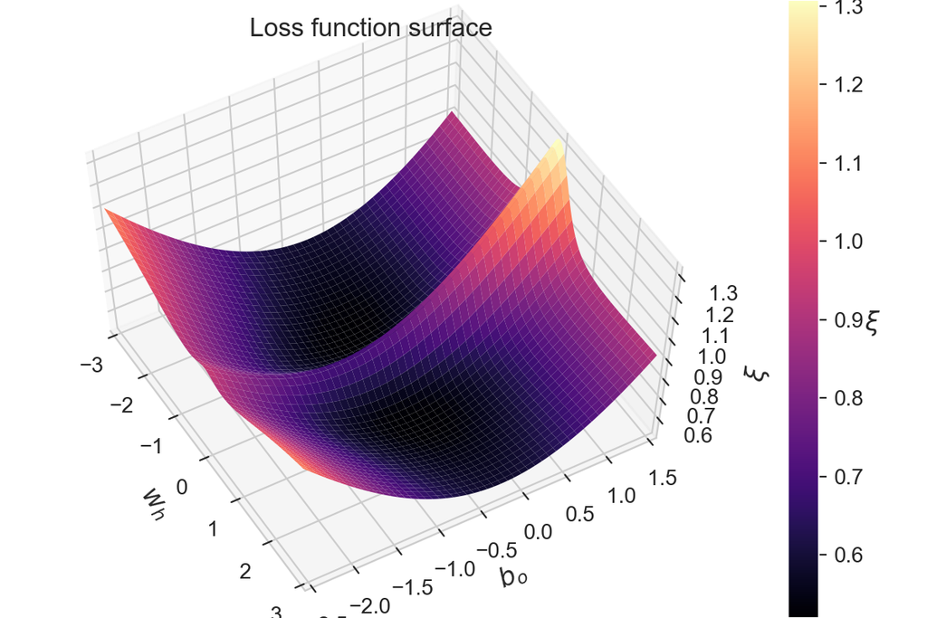

Nous voyons l'apparition de deux minima locaux, il est difficile lors de la minimisation de la loss de savoir dans quel creux se trouve la loss la plus basse.

L'algorithme d'optimisation utilisée pour entrainer les réseaux de neurones est l'algorithme de descente de gradient (Stochastic gradient descent) comme vu dans les précédentes sections. La SGD fonctionne en prenant le **gradient** (ou la dérivée) de la fonction loss $\xi$ en fonction des paramètres du réseau.

**Définition :** La dérivée mesure l'ampleur du changement d'une fonction de sortie (ici notre loss) par rapport à un changement de son entrée (ici nos poids). Le gradient est une généralisation à plusieurs variables (comme un NN) de la dérivée qui ne traite que les fonctions d'une variable.

Le gradient permet de trouver comment chaque poids a contribué à la loss. Il est donc possible de minimiser la fonction loss en mettant à jour chaque poids suivant la **négative** du gradient de manière itérative : c'est la **backward pass**.

Plus formellement, à chaque itération $k$, le poids $w$ est mis à jour en suivant : $$\mathbf{w}(k+1) = \mathbf{w}(k) - \Delta \mathbf{w}(k+1)$$ où le gradient $\Delta \mathbf{w} = \mu \frac{\partial \xi}{\partial \mathbf{w}}$ et $\mu$ est le pas d'apprentissage (appelé aussi learning rate). Le pas d'apprentissage définit donc l'importance avec laquelle le changement de direction est appliqué au poid.

Pour trouver ${\partial \xi_i}/{\partial \mathbf{w}}$ de l'exemple $i$, il suffit de remonter la chaîne de la forward pass pour connaitre comment $w$ a contribué à ${ \xi_i}$

. Si on considère que la prédiction $y_i$ était simplement engendrée par $w$, on pourrait écrire la chaine : $$\frac{\partial \xi_i}{\partial w} = \frac{\partial \xi_i}{\partial y_i} \frac{\partial y_i}{\partial w}$$ *Mais* nous avons utilisé la fonction sigmoide pour la prédiction. En effet, si l'on devait décrire notre système en entier, on définirait $y_i = \sigma(z_i)$, la sortie de la fonction logisitique et $z_i = \mathbf{x}_i \cdot \mathbf{w}^T$ l'entrée de la fonction logistique. On réécrit alors la chaîne : $$\frac{\partial \xi_i}{\partial \mathbf{w}} = \frac{\partial \xi_i}{\partial y_i} \frac{\partial y_i}{\partial z_i} \frac{\partial z_i}{\partial \mathbf{w}}$$ Nous n'allons pas déroulé la dérivée car ce n'est pas le but du cours. Le gradient est obtenu par l'expression suivante : $$\Delta \mathbf{w} = \mu \cdot \frac{1}{N} \sum_{i=1}^{N} \mathbf{x}_i (y_i - t_i)$$ Nous pouvons ainsi implémenter cette fonction et realiser la descente stochastique de gradient :

```python
def gradient(w, x, t):
    return (nn(x, w) - t).T * x

# On initilalise la matrice de manière aléatoire
w = np.asmatrix([-4,4])
# pas d'apprentissage
learning_rate = 0.05

nb_of_iterations = 10  # On choisit dix descentes de gradient
w_iter = []
l_iter = []
for i in range(nb_of_iterations):
    w_iter.append(w)  # on garde les poids pour le plot
    l_iter.append(loss(nn(X, w),y))  # on garde la loss pour le plot
    dw = gradient(w, X, y)  # calcul du gradient
    w = w - learning_rate * dw  # maj du poids

for l,m in zip(l_iter, w_iter):
    print("Loss:",l,"w:",m)
```

```
Loss: 3.397738202762406 w: [[-4  4]]
Loss: 2.7258153066468482 w: [[-3.25650149  3.10643653]]
Loss: 2.074322581668281 w: [[-2.52141824  2.22454942]]
Loss: 1.4676770441773184 w: [[-1.80888838  1.36361784]]
Loss: 0.9710496721769445 w: [[-1.15588633  0.55317126]]
Loss: 0.6985049062554499 w: [[-0.65766785 -0.11197573]]
Loss: 0.6291438634859079 w: [[-0.43803598 -0.49853019]]
Loss: 0.6150189294765884 w: [[-0.41147491 -0.68685891]]
Loss: 0.6090283230628221 w: [[-0.44173631 -0.79981828]]
Loss: 0.6053519207544842 w: [[-0.48253108 -0.88018438]]
```

La loss est bien de 0.6 comme estimé sur le plot. On peut maintenant dessiner les mis à jour des poids :

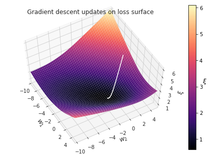

```python
# Plot the error surface
fig = plt.figure(figsize=(6, 4))
with sns.axes_style("whitegrid"):
    ax = Axes3D(fig)
surf = ax.plot_surface(
    params_x, params_y, loss_grid, linewidth=0, cmap=cm.magma)
ax.view_init(elev=60, azim=-30)
cbar = fig.colorbar(surf)
cbar.ax.set_ylabel('$\\xi$', fontsize=12, rotation=0)

# Plot the updates
for i in range(1, 10):
    w1 = w_iter[i - 1]
    w2 = w_iter[i]

    l1 = l_iter[i - 1]
    l2 = l_iter[i]

    # Plot the update
    ax.plot([w1[0,0], w2[0,0]], [w1[0,1], w2[0,1]], [l1, l2], 'w-')
# Show figure
ax.set_xlabel('$w_1$', fontsize=12)
ax.set_ylabel('$w_2$', fontsize=12)
ax.set_zlabel('$\\xi$', fontsize=12)
ax.set_ylim(-10, 5)
ax.set_xlim(-10, 5)
plt.title('Gradient descent updates on loss surface')
plt.show()
```

Comme vous l'avez vu dans les section précédentes, les librairies python deep-learning possèdent des outils de différentiation automatique et mettent à jour les poids automatiquement après chaque forward pass (selon le pas d'apprentissage que vous leur renseignez).